# PA1_template

### What is mean total number of steps taken per day?

1. following code calculates the total number of steps taken per day

```r
#add the number of steps for each day and aggregate the data by each day
step_sum <-sqldf("select date, sum(steps) as sumsteps from clean_data group by date")
```

2. Following code snippet creates the histogram of the total number of steps taken each day

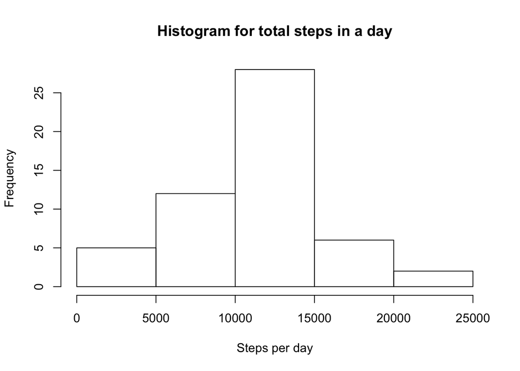

```r
#create the histogram
hist_graph <- hist(step_sum$sumsteps, main="Histogram for total steps in a day",xlab="Steps per day",ylab="Frequency")
```

3. Following code snippet calculates the mean and median of total number of steps taken per day

```r
#calculate mean and median for daily total number of steps
daily_mean <- as.integer(mean(step_sum$sumsteps))
daily_median <- as.integer(median(step_sum$sumsteps))
```

Daily mean is 10766 Daily median is 10765

### What is the average daily activity pattern?

1. Following code snippet creates the time series plot of the 5-minute interval and the average number of steps taken, averaged across all days

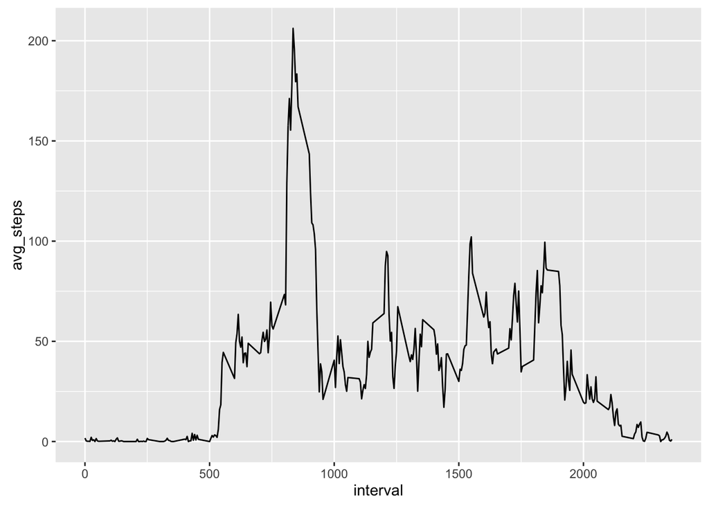

```r
avg_daily_act <- sqldf("select interval, avg(steps) as avg_steps from clean_data group by interval")
max_avg_daily_act <- sqldf("select interval, max(avg_steps) as max_avg from avg_daily_act")
max_interval <- max_avg_daily_act$interval
max_avg_steps <- as.integer(max_avg_daily_act$max_avg)
ggplot(avg_daily_act, aes(interval, avg_steps))  + geom_line()
```

2. Interval 835 has the maximum number of steps 206 on average across all days in the dataset

### Imputing missing values

```r
missingvalues <- sum(is.na(rawdata$steps))
```

There are 2304 rows with missing values in the dataset

Replace the missing values in the data set with the mean of all the steps

```r
clean_data_1 <- rawdata
clean_data_1$steps[which(is.na(clean_data_1$steps))] <- mean(clean_data$steps)
```

Get the total number of steps per day and create a histogram

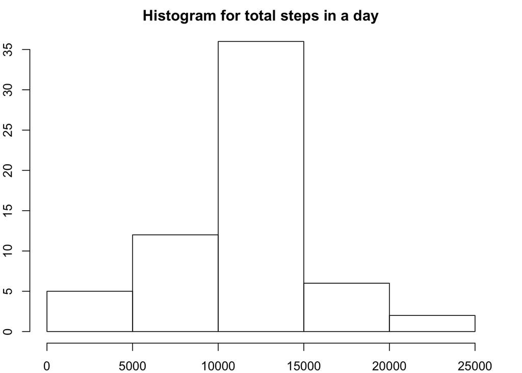

```r
step_sum <-sqldf("select date, sum(steps) as sumsteps from clean_data_1 group by date")
#png("plot1.png",height=600,width = 800)
par(mar = rep(2, 4))
hist_graph<-hist(step_sum$sumsteps, main="Histogram for total steps in a day",xlab="Steps per day",ylab="Frequency")
```

Calculate the new mean and median of the total number of steps per day

```r
daily_mean_1 <- as.integer(mean(step_sum$sumsteps))
daily_median_1 <- as.integer(median(step_sum$sumsteps))
```

New mean is 10766 and new median is 10766

Create a vector that stores if the date in the cleaned date is a weekday or a weekend, then append that vector to the cleaned data set

```r
wkdy <- vector(mode="logical",length=nrow(clean_data_1))
rowcount <- nrow(clean_data_1)
rownumber <- 0

for (rownumber in 1:rowcount) {
 if (isWeekday(clean_data_1[rownumber,2])) {
   wkdy[rownumber] <- "weekday"
  }
  if (isWeekend(clean_data_1[rownumber,2])){
    wkdy[rownumber] <- "weekend"
   }
}

clean_data_1 <- cbind(clean_data_1,wkdy)
```

Calculate the averages across intervals on weekdays and weekends

```r
avg_weekday <- sqldf("select interval, avg(steps) as avg_steps, wkdy from clean_data_1 where wkdy='weekday' group by interval")
avg_weekend <- sqldf("select interval, avg(steps) as avg_steps, wkdy from clean_data_1 where wkdy='weekend' group by interval")
```

Plot of avg across intervals on weekdays and weekends

```r
attach(mtcars)
```

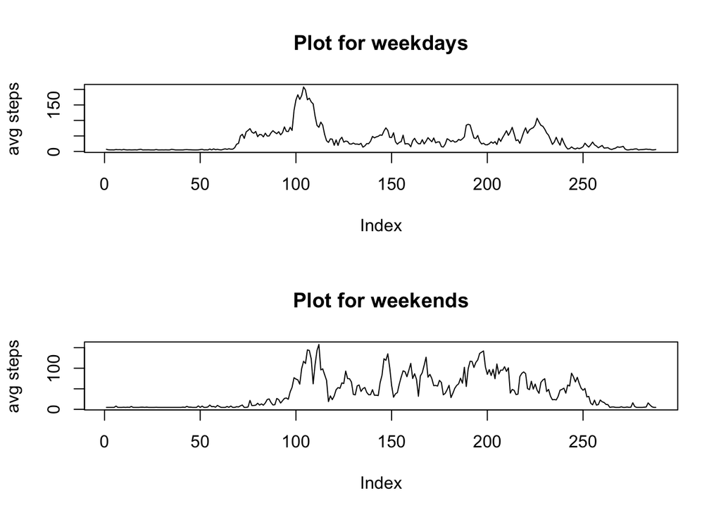

```r
par(mfrow=c(2,1))
plot(avg_weekday$avg_steps, type="l", main="Plot for weekdays", ylab="avg steps")
plot(avg_weekend$avg_steps, type="l", main="Plot for weekends",ylab="avg steps")
```